# DataCovid : quelques éléments d’analyse avec un oeil sur le masque

cb

27/09/2020

[figure not shown]

source : https://streetarts.blog/2020/05/16/bas-les-masques/

## 0 - Libraries de travail

```r
knitr::opts_chunk$set(echo = TRUE,message=FALSE,warning = FALSE, cache=TRUE)
library(tidyverse) #le canif suisse de la datascience
library(reshape2) #passer d'un fichier large à long
library(psych) #psychométrie et analyse factorielle
library(readr)
library(data.table)
library(corrplot) #diagramme de corrélation
library(ggeffects)
library(jtools)
library(sjPlot)
library(sjmisc)
library(kableExtra) #pour de jolis tableaus
library(lme4) #audelà de l'OLS
library(gridExtra) #assembler les graphes
```

## 1 - les données

Elles proviennent de 8 vagues d’enquêtes réalisées par Ipsos pour le baromètre [DataCovid](https://datacovid.org/), de 5000 individus chacune; de avril à juin 2020. Voir le script `dataprep` pour la procédure de compilation et de recodage.

La période de temps va de avril à juin. Elle manque l’avant confinement, et sa première période, elle couvre le déconfinement mais ne va pas jusqu’à l’été. A cette date, la rentrée se présente avec un regain, fruit du brassage des vacances et des regroupements estudiantiens. Fin septembre une seconde vague doit être constatée. Le port du masque est devenu obligatoire en de nombreux endroits, dans la plus part des villes, aux croisements de transports )publics, des centres commerciaux et des bureaux.

```r
df<-readRDS("df.rds")
```

## 2 - Analyse de l’évolution des préoccupations

Une première question est de savoir dans quelle mesure les sujets de préoccupations évoluent.

Question A0 : Parmi les sujets suivants, quelles sont les trois qui vous semblent les plus préoccupants aujourd’hui, pour vous personnellement ? (Colonne A0_0 : Préoccupation 1, A0_1 : Préocupation 2, A0_2 : Préoccupation 3). Valeurs possibles :

1 : L’épidémie de coronavirus 2 : Le pouvoir d’achat 3 : Le changement climatique 4 : Les inégalités sociales 5 : Le chômage 6 : Les déficits publics et de la dette de l’État 7 : L’éducation 8 : Le système de santé 9 : L’insécurité 10 : Le terrorisme

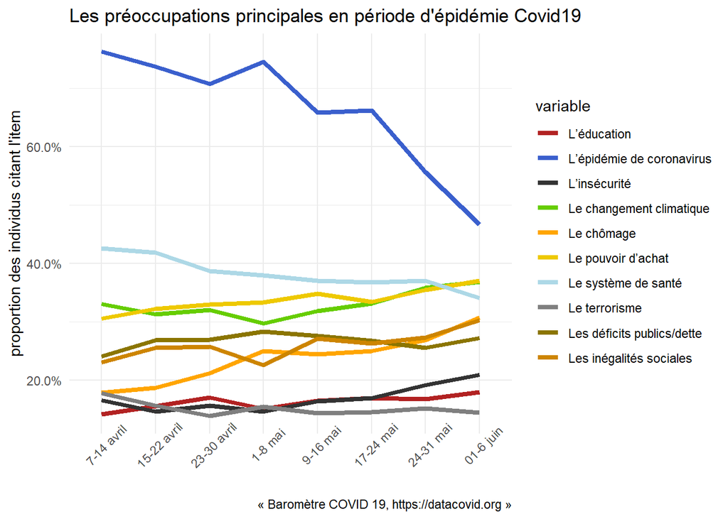

```r
#preoccupations : recodage des trois variables nominales en 10 variables binaires

df<-df %>% mutate(p_01=ifelse(A0_0==1 | A0_1==1 | A0_2==1,1,0))
df<-df %>% mutate(p_02=ifelse(A0_0==2 | A0_1==2 | A0_2==2,1,0))
df<-df %>% mutate(p_03=ifelse(A0_0==3 | A0_1==3 | A0_2==3,1,0))
df<-df %>% mutate(p_04=ifelse(A0_0==4 | A0_1==4 | A0_2==4,1,0))
df<-df %>% mutate(p_05=ifelse(A0_0==5 | A0_1==5 | A0_2==5,1,0))
df<-df %>% mutate(p_06=ifelse(A0_0==6 | A0_1==6 | A0_2==6,1,0))
df<-df %>% mutate(p_07=ifelse(A0_0==7 | A0_1==7 | A0_2==7,1,0))
df<-df %>% mutate(p_08=ifelse(A0_0==8 | A0_1==8 | A0_2==8,1,0))
df<-df %>% mutate(p_09=ifelse(A0_0==9 | A0_1==9 | A0_2==9,1,0))
df<-df %>% mutate(p_10=ifelse(A0_0==10 | A0_1==10 | A0_2==10,1,0))

foo<-df  %>% select(VAGUE2,p_01,p_02,p_03,p_04,p_05,p_06,p_07,p_08,p_09,p_10)

foo<-melt(foo,id=c("VAGUE2"))%>%
  group_by(VAGUE2,variable) %>%
  summarise(frequence=mean(value))

#on renomme les variables pour une meilleure lecture
foo$variable<-as.character(foo$variable)
foo$variable[foo$variable=="p_01"]<-"L’épidémie de coronavirus"
foo$variable[foo$variable=="p_02"]<-"Le pouvoir d’achat"
foo$variable[foo$variable=="p_03"]<-"Le changement climatique"
foo$variable[foo$variable=="p_04"]<-"Les inégalités sociales"
foo$variable[foo$variable=="p_05"]<-"Le chômage"
foo$variable[foo$variable=="p_06"]<-"Les déficits publics/dette"
foo$variable[foo$variable=="p_07"]<-"L’éducation"
foo$variable[foo$variable=="p_08"]<-"Le système de santé"
foo$variable[foo$variable=="p_09"]<-"L’insécurité"
foo$variable[foo$variable=="p_10"]<-"Le terrorisme"

foo$variable<-as.factor(foo$variable)

col=c("firebrick","Royalblue3","grey20","chartreuse3","orange1","gold2","lightblue","grey50","gold4","orange3")

ggplot(foo,aes(x=VAGUE2 ,y=frequence,group=variable))+
  geom_line(aes(color=variable),size=1.5)+
  theme_minimal()+
  labs(title = "Les préoccupations principales en période d'épidémie Covid19",x =NULL,y="proportion des individus citant l'item",caption = "« Baromètre COVID 19, https://datacovid.org »",ylab="vague d'enquête")+
  scale_color_manual(values=col)+
  theme(axis.text.x = element_text(angle=45))+
  scale_y_continuous(labels = scales::percent_format(accuracy=.1))
```

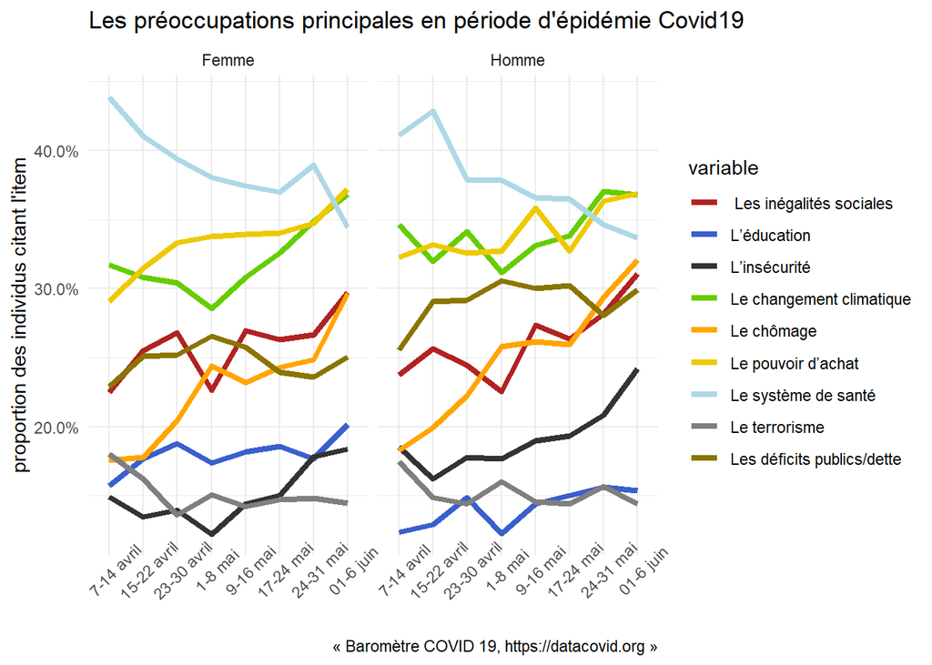

```r
#par categorie
foo<-df  %>% select(VAGUE2,SEXE,p_02,p_03,p_04,p_05,p_06,p_07,p_08,p_09,p_10)
foo<-melt(foo,id=c("VAGUE2","SEXE"))%>% group_by(VAGUE2,variable, SEXE) %>% summarise(frequence=mean(value))


foo$variable<-as.character(foo$variable)
foo$variable[foo$variable=="p_01"]<-"L’épidémie de coronavirus"
foo$variable[foo$variable=="p_02"]<-"Le pouvoir d’achat"
foo$variable[foo$variable=="p_03"]<-"Le changement climatique"
foo$variable[foo$variable=="p_04"]<-" Les inégalités sociales"
foo$variable[foo$variable=="p_05"]<-"Le chômage"
foo$variable[foo$variable=="p_06"]<-"Les déficits publics/dette"
foo$variable[foo$variable=="p_07"]<-"L’éducation"
foo$variable[foo$variable=="p_08"]<-"Le système de santé"
foo$variable[foo$variable=="p_09"]<-"L’insécurité"
foo$variable[foo$variable=="p_10"]<-"Le terrorisme"

foo$variable<-as.factor(foo$variable)

col=ccol=c("firebrick","Royalblue3","grey20","chartreuse3","orange1","gold2","lightblue","grey50","gold4","orange3")


ggplot(foo,aes(x=VAGUE2 ,y=frequence,group=variable))+geom_line(aes(color=variable),size=1.5)+
  theme_minimal()+
  labs(title = "Les préoccupations principales en période d'épidémie Covid19",x =NULL,y="proportion des individus citant l'item",caption = "« Baromètre COVID 19, https://datacovid.org »",ylab="vague d'enquête")+
  scale_color_manual(values=col)+
  theme(axis.text.x = element_text(angle=45))+
  scale_y_continuous(labels = scales::percent_format(accuracy=.1))+facet_wrap(vars(SEXE),ncol=2)
```

### Corrélations entre les préoccupations

Examinons les corrélations entre ces éléments

Si elle sont toutes négatives, ou presque, c’est que compte tenu de la contrainte citer plus l’une décroît la probabilité de citation des autres proccupations. On les calcule vague par vague .

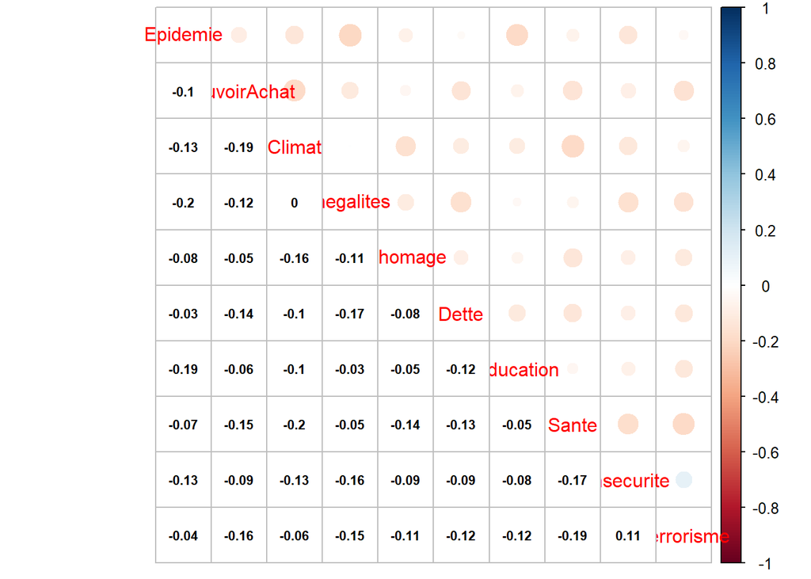

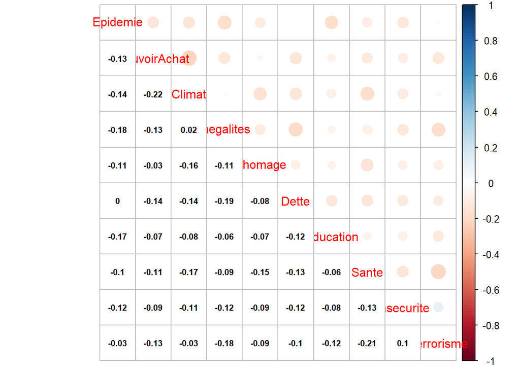

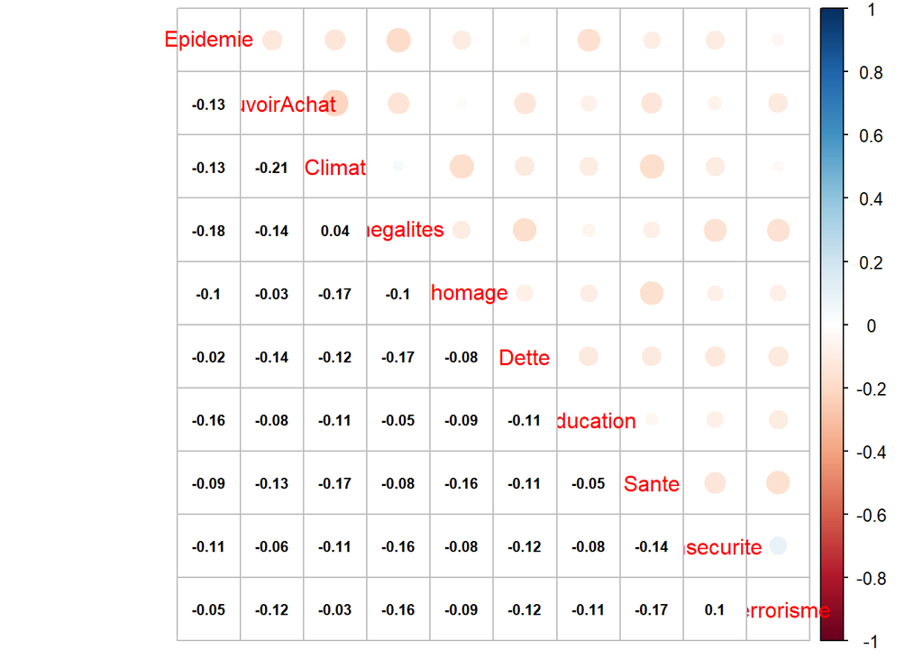

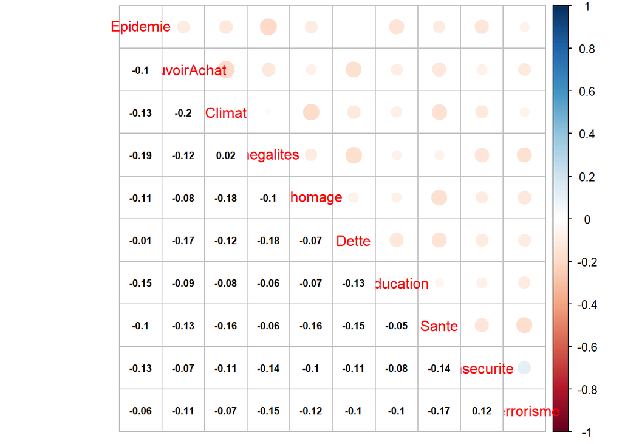

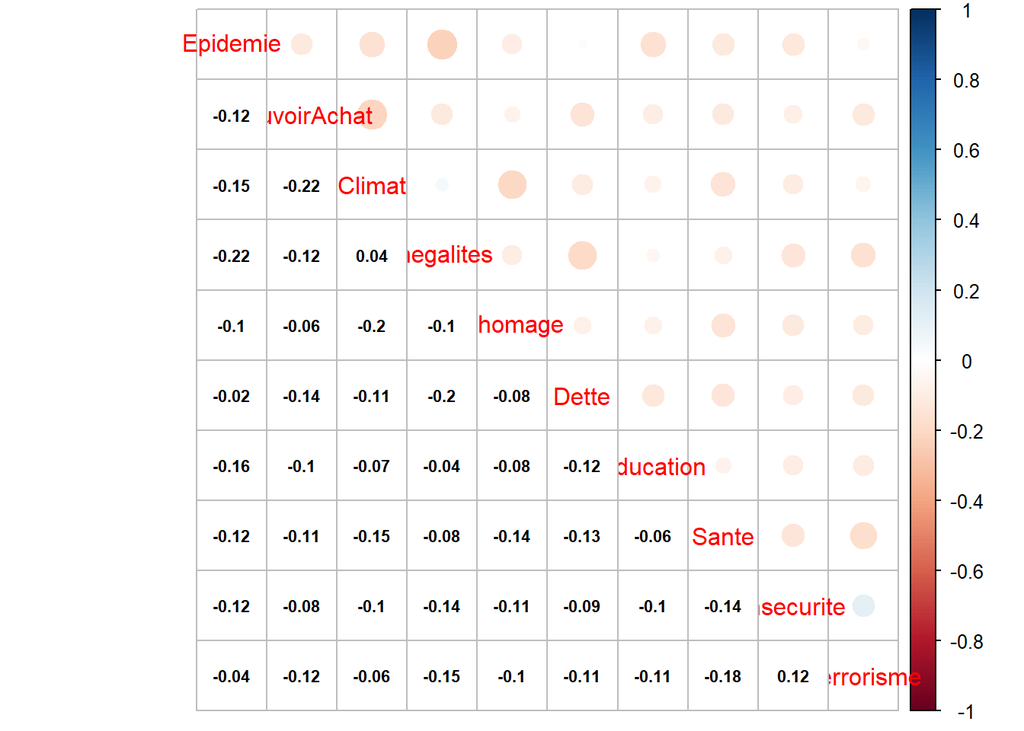

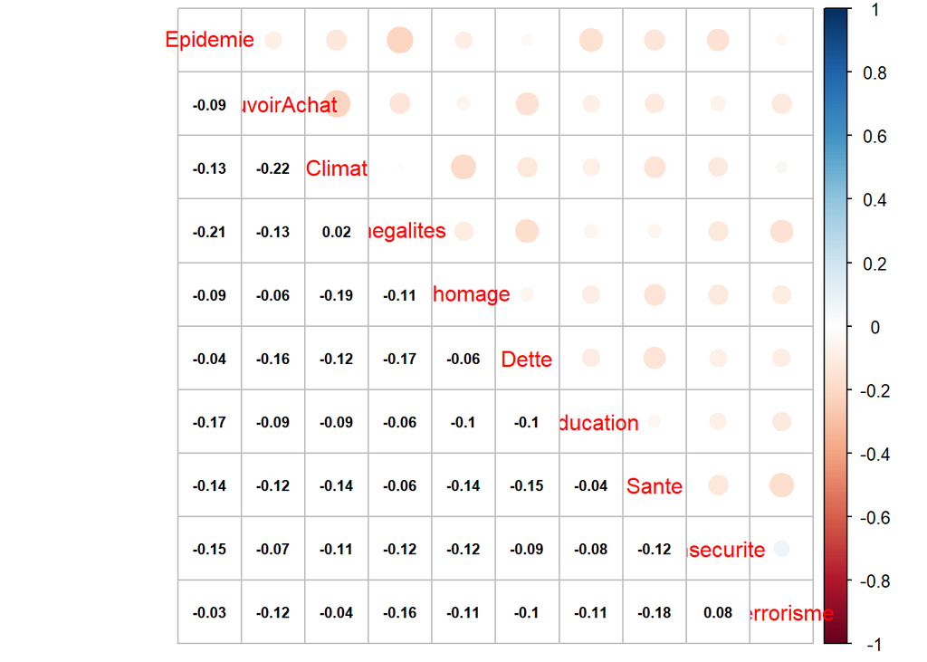

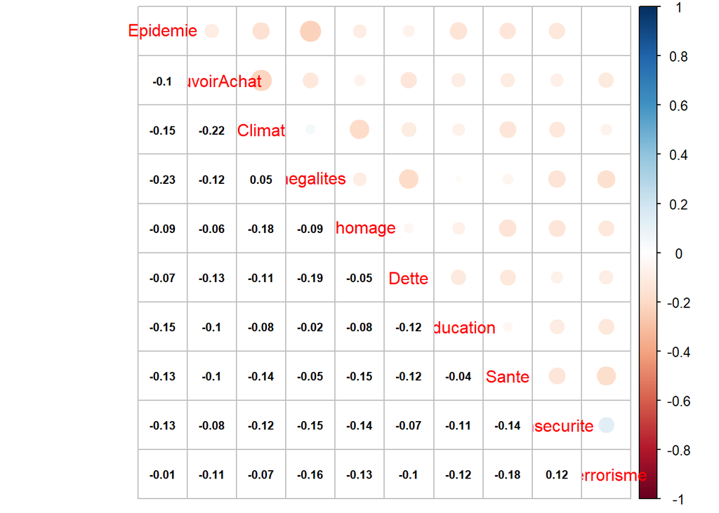

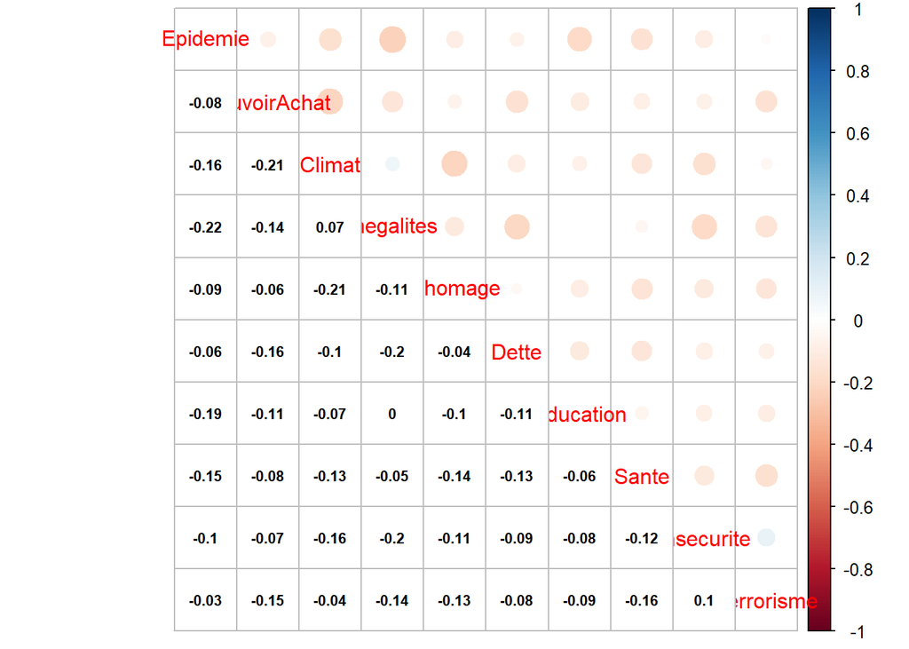

```r
#library(corrplot)

for (i in 1:8){
foo<-df  %>% filter(VAGUE==i)%>%select(p_01,p_02,p_03, p_04,p_05,p_06,p_07,p_08,p_09,p_10) %>% rename(Epidemie=p_01,PouvoirAchat=p_02,Climat=p_03,Inegalites=p_04,Chomage=p_05, Dette=p_06,Education=p_07,Sante=p_08,Insecurite=p_09, Terrorisme=p_10)
r<-cor(foo)
corrplot.mixed(r, lower.col = "black", number.cex = .7)
}
```

Pour les méthodes typologiques [voir par ex](https://sites.google.com/site/rgraphiques/4--stat/clustering-hierarchique)

Pour l’analyse muldidimensionnelle des [proximités voir par ex] (http://www.normalesup.org/~carpenti/Notes/MDS/MDS-simple.html)

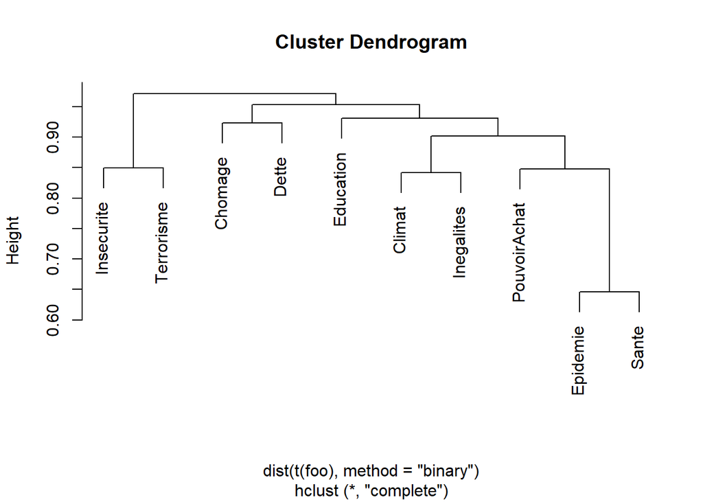

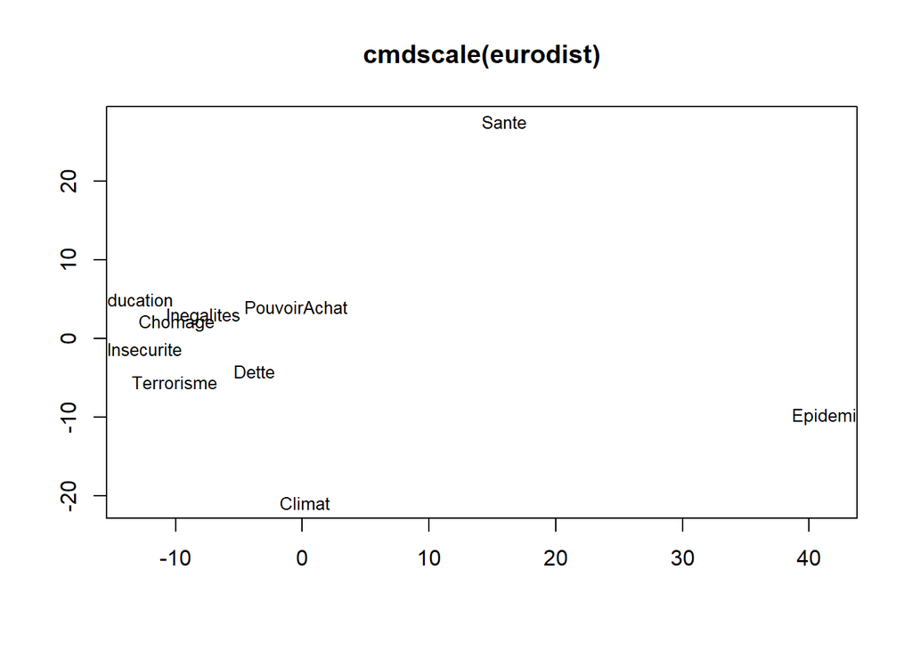

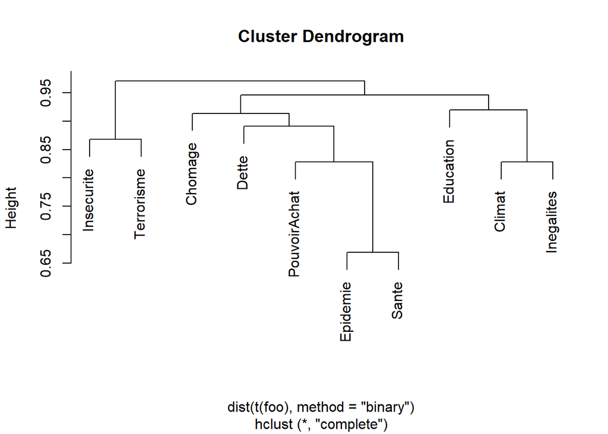

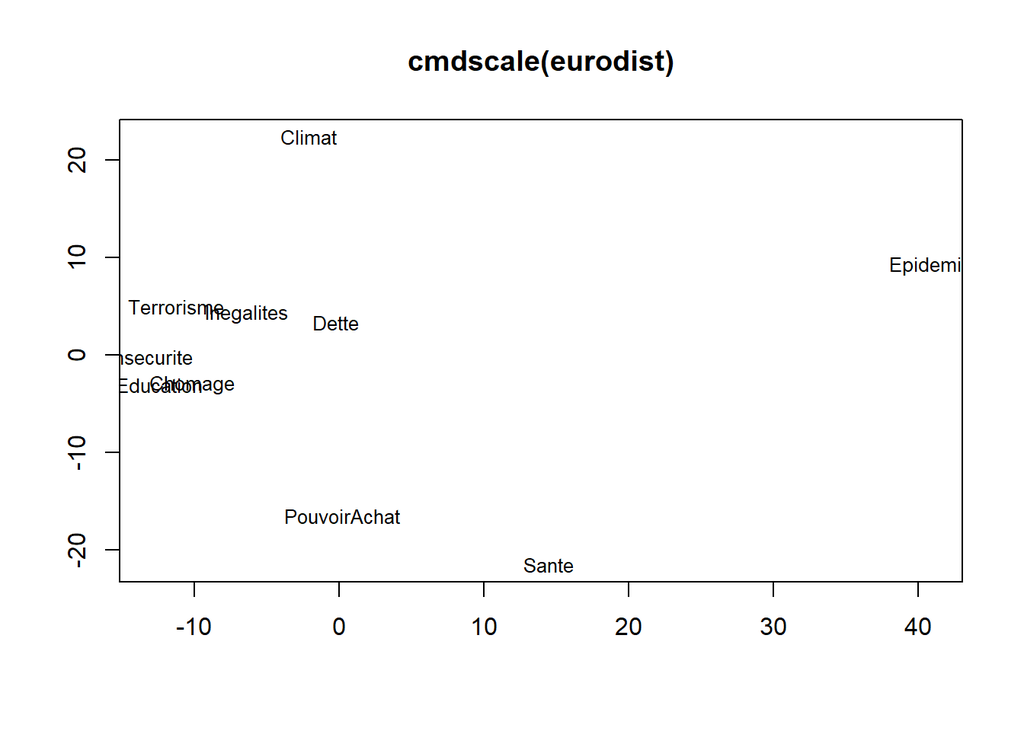

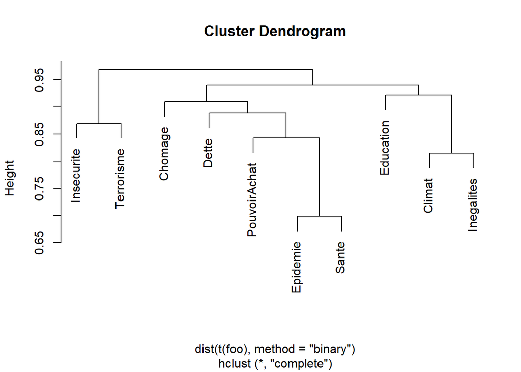

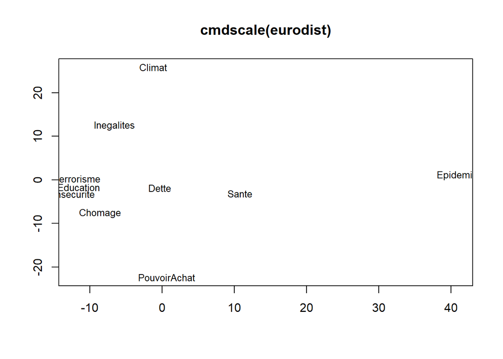

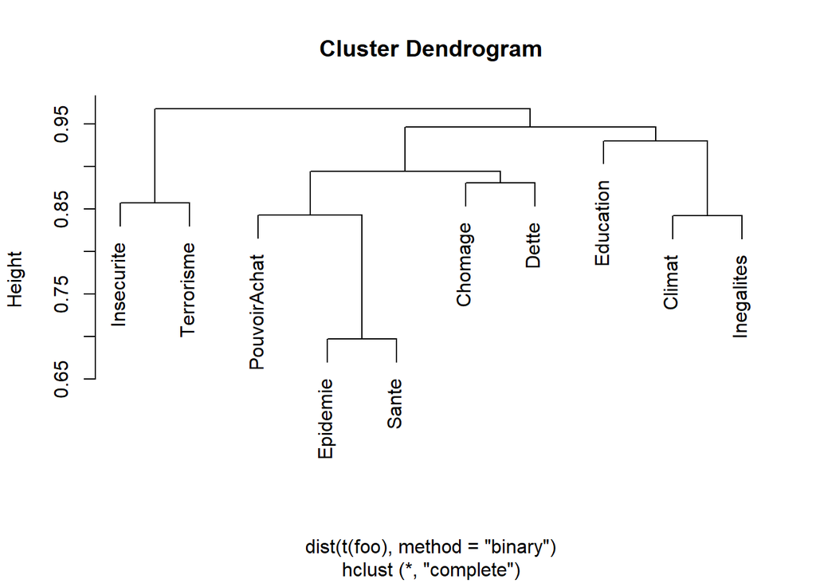

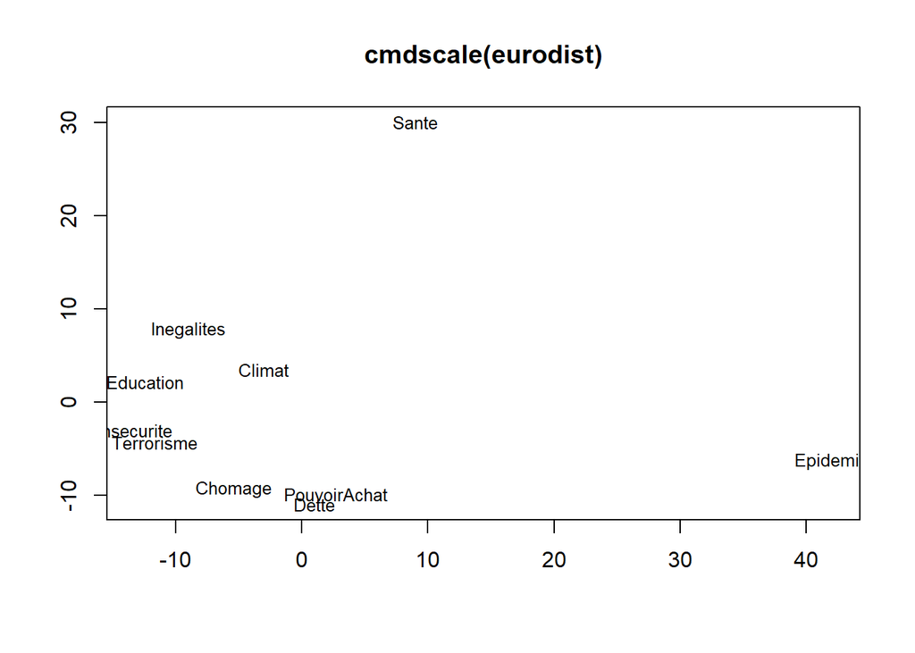

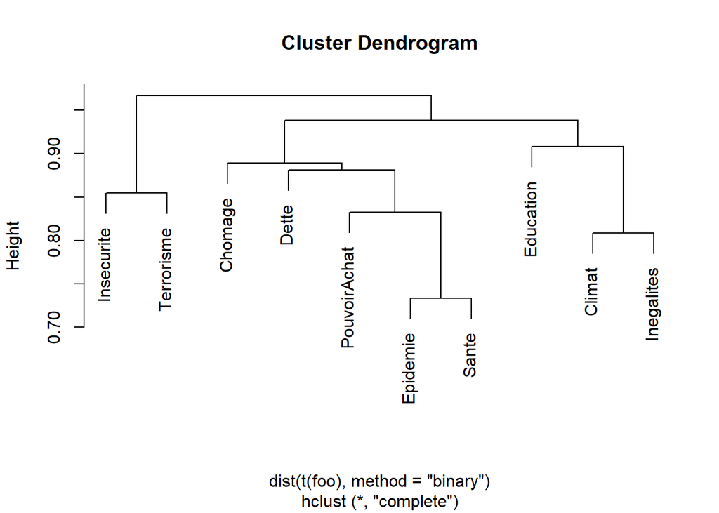

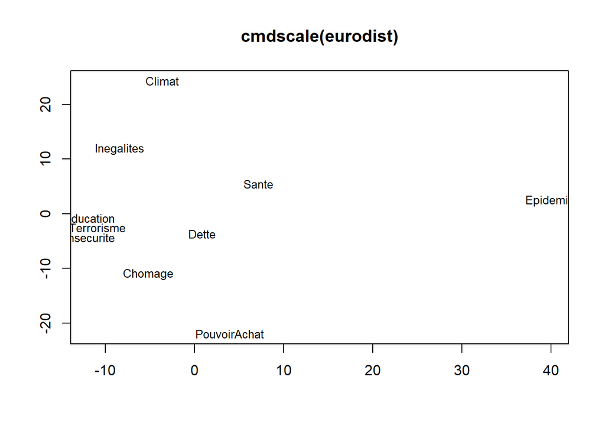

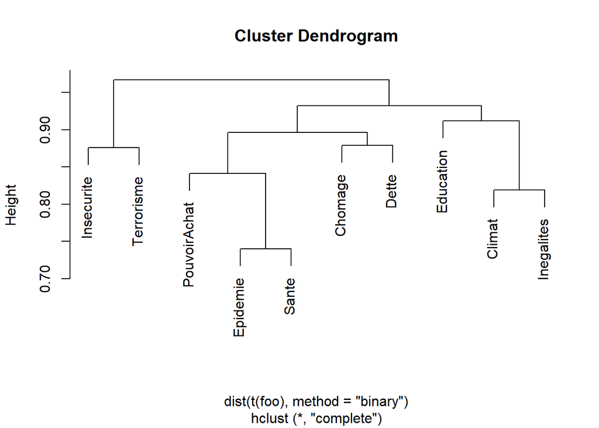

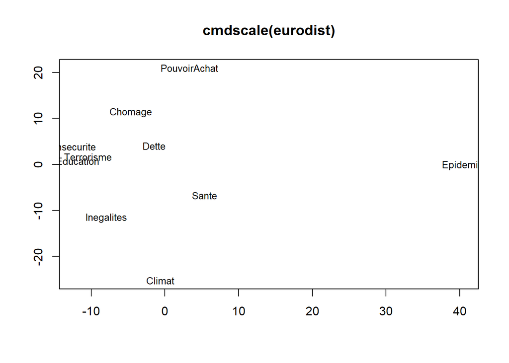

[4 more figures not shown]

```r
for (i in 1:8){
foo<-df  %>% filter(VAGUE==i)%>%select(p_01,p_02,p_03, p_04,p_05,p_06,p_07,p_08,p_09,p_10) %>% rename(Epidemie=p_01,PouvoirAchat=p_02,Climat=p_03,Inegalites=p_04,Chomage=p_05, Dette=p_06,Education=p_07,Sante=p_08,Insecurite=p_09, Terrorisme=p_10)
hr <- hclust(dist(t(foo),method="binary"), method = "complete")
plot(hr)
loc <- cmdscale(dist(t(foo)), k=2,add=FALSE )
plot(loc[,1], -loc[,2], type="n", xlab="", ylab="", main="cmdscale(eurodist)")
text(loc[,1], -loc[,2], rownames(loc), cex=0.8)
}
```

## 3 - Perception de la gravité de l’épidémie

L’évolution des préoccupations sur cette période est marqué par le sentiment que l’urgence de l’épidémie recule et que la crise est économique : elle menace de chomage de de perte de pouvoir d’achat, elle s’inscrit aussi dans une perspective environnementale. Ce qui correspond aux statistiques publiées quotidiennement sur cette période et qui montre une régression du choc épidémique.  
Dans cette section l’objectif est d’examiner l’évolution de la perception de la gravité de l’épidémie dans la perspective qu’elle est déterminante dans le degré d’observance des gestes barrières, et d’en avoir une première idée des déterminants sociaux.

Q2.1. Sur une échelle de 0 à 10, comment évaluez-vous la gravité de l’épidémie de coronavirus aujourd’hui ? 0 voulant dire que selon vous elle n’est actuellement pas grave du tout. 10 voulant dire que selon vous elle est extrêmement grave. Les notes intermédiaires vous permettant de préciser votre jugement. I_**I**_I / 10

### 3.1 - Evolution de la perception de la gravité par âge.

On examine d’abord l’effet de l’âge dont la priorité se justifie par l’extrême différence de l’impact de la maladie. Elle n’affecte pas les plus jeunes et tue les plus vieux. On s’attend donc raisonnablement, que chaque classe d’age ayant cette connaissance sociale, apprécie en fonction de sa connaissance du risque, la gravité de l’épidémie.

Ce qu’on observe est clair, alors que la perception de la gravité décroît de manière homogène à travers les classes d’âge, les plus vieux sont plus inquiets que les plus jeunes.

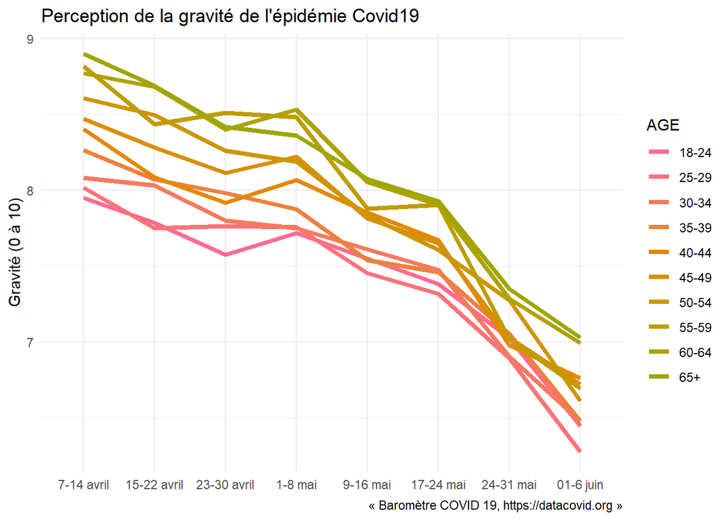

```r
foo<-df  %>% select(VAGUE2,B1Q,AGE)
foo<-melt(foo)

foo<-foo %>% group_by(AGE,VAGUE2) %>% summarise(Gravite=mean(value, na.rm = TRUE))

g0<-ggplot(foo,aes(x=VAGUE2 ,y=Gravite,group=AGE))+
  geom_line(aes(color=AGE),size=1.5)+  theme_minimal()+
  labs(title = "Perception de la gravité de l'épidémie Covid19",x =NULL,y="Gravité (0 à 10)",caption = "« Baromètre COVID 19, https://datacovid.org »")+
  scale_colour_hue(h = c(0, 90))
g0
```

La description graphique est cependant insuffisante pour apprécier les effets. Si l’évolution dans le temps est décroissante et que les différences d’âges sont systématiques on croit remarquer une variance moindre dans les dernières vagues que dans les premières, dénotant une interaction possible : la décroissance de la perception de gravité est d’autant plus forte que les population sont agées.

Un test est nécessaire, on emploie une ANOVA à deux facteurs plus une interaction. Pour [plus de détail voir](http://www.sthda.com/english/wiki/two-way-anova-test-in-r). On réalise le test d’abord en retenant les catégories, puis en les supposant numérique ( avec un effet linéaire).

On utilise les fonctions effect_plot, summ et plot_summs du package `jtools` qui permet de présenter les résultats de manière élégantes. Diagramme de paramètre et diagrammes d’effets étaient peu employée, ils le sont de plus en plus facilitant l’analyse des effets

```r
foo<-df  %>% select(VAGUE2,B1Q,AGE)
m0<-lm(B1Q~AGE*VAGUE2,data=foo)
anova(m0)
```

```
## Analysis of Variance Table
##
## Response: B1Q
##               Df Sum Sq Mean Sq  F value  Pr(>F)
## AGE            9   2418  268.62  75.1457 < 2e-16 ***
## VAGUE2         7  13161 1880.11 525.9536 < 2e-16 ***
## AGE:VAGUE2    63    363    5.76   1.6113 0.00153 **
## Residuals  39921 142704    3.57
## ---
## Signif. codes:  0 '***' 0.001 '**' 0.01 '*' 0.05 '.' 0.1 ' ' 1
```

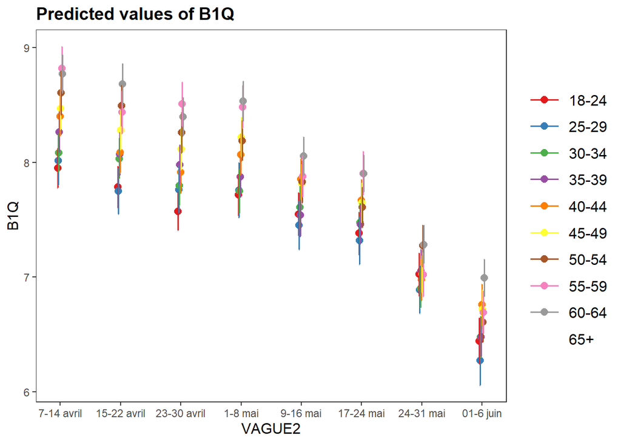

```r
plot_model(m0, type = "pred", terms = c("VAGUE2", "AGE"))+theme_apa()
```

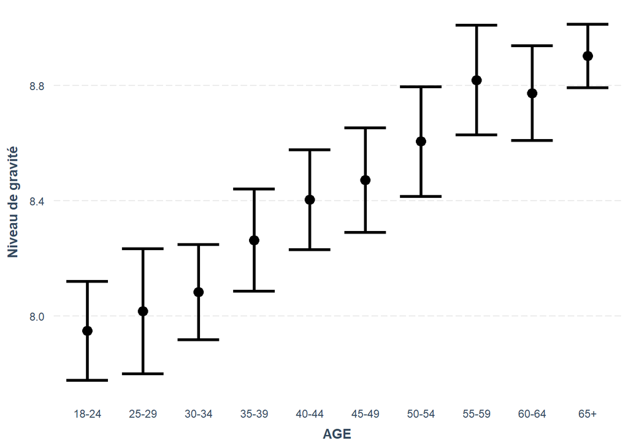

```r
effect_plot(m0, pred = AGE, interval = TRUE, plot.points = FALSE, y.label = "Niveau de gravité")
```

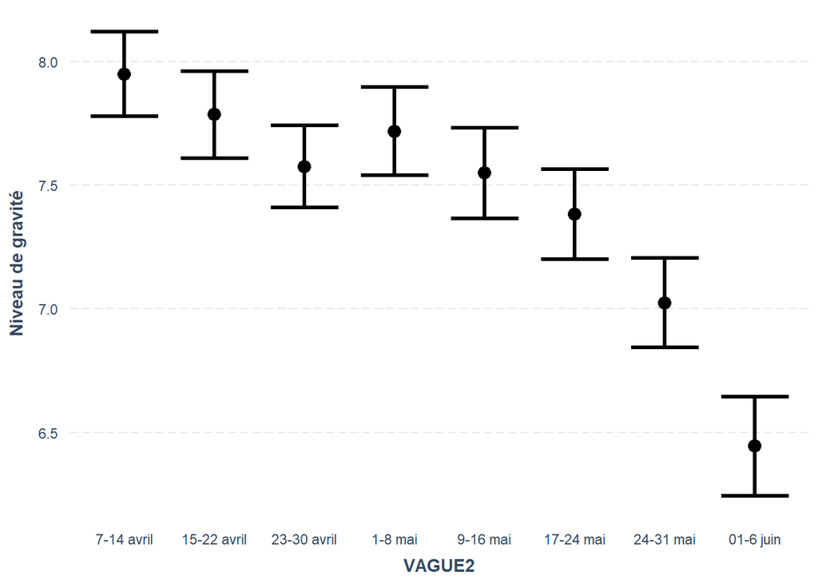

```r
effect_plot(m0, pred = VAGUE2, interval = TRUE, plot.points = FALSE,y.label = "Niveau de gravité")
```

```r
foo<-df  %>% select(VAGUE,B1Q,AGE2)
foo$AGE2<-5*foo$AGE2+17

m1<-lm(B1Q~AGE2*VAGUE,data=foo)
anova(m1)
```

```
## Analysis of Variance Table
##
## Response: B1Q
##               Df Sum Sq Mean Sq  F value    Pr(>F)
## AGE2           1   2366  2366.4  656.933 < 2.2e-16 ***
## VAGUE          1  12069 12069.4 3350.576 < 2.2e-16 ***
## AGE2:VAGUE     1    133   132.9   36.903 1.253e-09 ***
## Residuals  39997 144077     3.6
## ---
## Signif. codes:  0 '***' 0.001 '**' 0.01 '*' 0.05 '.' 0.1 ' ' 1
```

```r
summ(m1)
```

| Observations | 40001 |
| --- | --- |
| Dependent variable | B1Q |
| Type | OLS linear regression |

| F(3,39997) | 1348.14 |
| --- | --- |
| R² | 0.09 |
| Adj. R² | 0.09 |

|  | Est. | S.E. | t val. | p |
| --- | --- | --- | --- | --- |
| (Intercept) | 7.73 | 0.07 | 112.52 | 0.00 |
| AGE2 | 0.02 | 0.00 | 17.51 | 0.00 |
| VAGUE | -0.16 | 0.01 | -11.61 | 0.00 |
| AGE2:VAGUE | -0.00 | 0.00 | -6.07 | 0.00 |

Standard errors: OLS

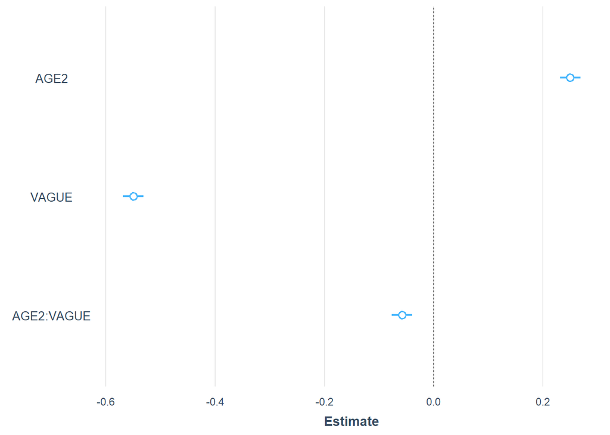

```r
plot_summs(m1, scale = TRUE)
```

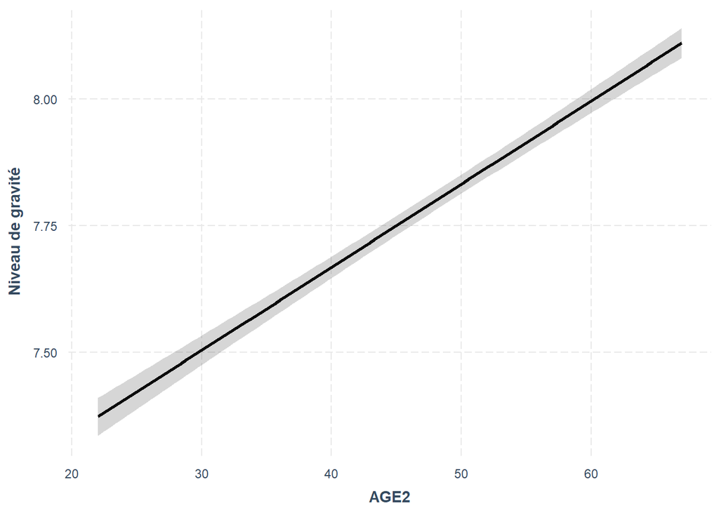

```r
effect_plot(m1, pred = AGE2, interval = TRUE, plot.points = FALSE, y.label = "Niveau de gravité")
```

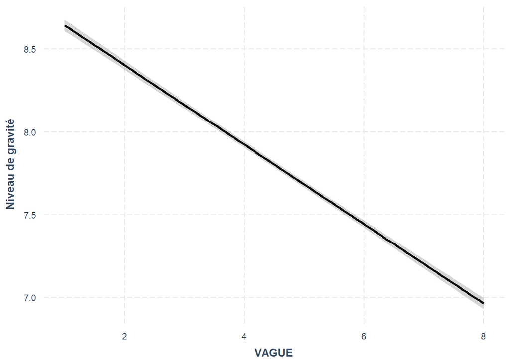

```r
effect_plot(m1, pred = VAGUE, interval = TRUE, plot.points = FALSE,y.label = "Niveau de gravité")
```

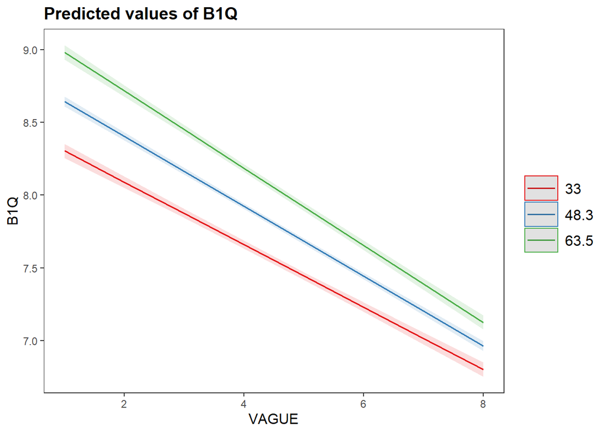

```r
plot_model(m1, type = "pred", terms = c("VAGUE", "AGE2"),y.label = "Niveau de gravité")+theme_apa()
```